# vtuberのyoutubeチャンネル登録者数について

エンタメだけじゃなく、行政や企業などの広報としても注目が集まり(※3)、総数は9000人(※4)にも及ぶ一大ムーブメントであるvtuberやそれを取り巻くバーチャルビジネス。

これらの基盤となるバーチャルリアリティを支援するファンドも開設されている(※5)。これを社会現象と言わずしてなんとするか。

一方で、元々は人々の趣味として始まったであろうvtuberがビジネスのステージにシフトしていることからこの狭間で活動を終了する存在も少なくない。

加えて、誰もがスマホ一つで参加出来ることから市場はレッドオーシャンと化し、収益に繋げることが難しくなってきている。

そこで、収益をあげるような著名なVtuber達からそのヒットの要因を探りたい。

vtuberを構成する大きな要素は“魂”と“容姿”の2つであると考える。

久遠千歳の転生の件からvtuberの構成要素の中で”魂”が占める割合は極めてが大きいことが考えられる。

しかし、ここでいう魂とは傍目からはブラックボックスであり評価を行うことが出来ない。

そこで他にvtuberを構成する要素として大きいのは見た目、キャラクターデザインだと考える。

これは第一印象が6~9割の印象を与えるという通説に基づく。この通説はビジネスや恋愛などの領域で言われている。

いずれにせよ大きく第一印象が大きくその後の評価に影響を与えることがわかる。

よって、vtuberの容姿、つまるところキャラクターデザインがvtuberの人気と密接に関係すると考える。

容姿の優劣を数値で測ることが出来ないため、ここでは容姿でなく、容姿を設定する存在の人気度こそがvtuberの人気と関係すると考える。

またここでは、その存在を通例に習って"ママ"と称する。

※3 moguravr(2019) VTuberのビジネス活用事例まとめ。接客販売や企業・自治体広報、イベントMCなど活躍

(https://www.moguravr.com/vtuber-business-case-summary/)(2020年1月17日最終閲覧)

backyard(2019) 企業のVTuber活用事例から、今後のヒントを探る！

(https://backyard.imjp.co.jp/articles/vtuber2019)(2020年1月17日最終閲覧)

※4 moguravr(2019) VTuberの総数が9000人を突破

(https://www.moguravr.com/vtuber-9000/)(2020年1月17日最終閲覧)

※5 MUFG(2019) ｅＭＡＸＩＳ Ｎｅｏ バーチャルリアリティ交付目論見書

(https://www.am.mufg.jp/pdf/koumokuromi/253482/253482_20191119.pdf)(2020年1月17日最終閲覧)

```python
import pandas as pd
import numpy as np
import time

# plot
from IPython.core.display import display
import seaborn as sns
import matplotlib.pyplot as plt
%matplotlib inline
plt.rcParams['font.family'] = 'AppleGothic'
import plotly
from plotly import tools
import plotly.graph_objs as go
plotly.offline.init_notebook_mode(connected=False)
import plotly.express as px

# analysis
from sklearn.linear_model import LinearRegression
from sklearn import preprocessing
import statsmodels.api as sm
```

下記の２つのサイトからスクレイピングして収集したデータと、独自収集のフォロワー数並びにママ情報を用いる。

- https://vtuber.jp/channels
- https://vtuber-insight.com/

```python
# read csv
df = pd.read_csv('df.csv')
df['start_date'] = pd.to_datetime(df['start_date'])
```

## データの確認

```python
display(df.head())
display(df.info())
```

|  | name | fans | views | posts | start_date | channel | twitter_id | affiliation | group | mama | mama_id | follower | mama_follower |
| --- | --- | --- | --- | --- | --- | --- | --- | --- | --- | --- | --- | --- | --- |
| 0 | キズナアイ | 2690000 | 278946277 | 783 | 2016-10-19 | A.I.Channel | @aichan_nel | upd8 | upd8 | 森倉円 | @morikuraen | 536114 | 298045.0 |
| 1 | 輝夜月 | 999000 | 98548785 | 103 | 2017-12-05 | Kaguya Luna Official | @_KaguyaLuna | THE MOON STUDIO | THE MOON STUDIO | Mika Pikazo | @MikaPikaZo | 437296 | 408535.0 |
| 2 | ミライアカリ | 739000 | 65460682 | 262 | 2014-03-01 | Mirai Akari Project | @MiraiAkari_prj | 株式会社DUO | ENTUM | KEI | @keigarou | 338712 | 37446.0 |
| 3 | シロ | 707000 | 103372761 | 990 | 2017-06-23 | Siro Channel | @SIROyoutuber | 株式会社アップランド | .LIVE | NaN | NaN | 298097 | NaN |
| 4 | 猫宮ひなた | 529000 | 40396427 | 177 | 2018-02-11 | ひなたチャンネル (Hinata Channel) | @Nekomiya_Hinata | 株式会社DUO | ENTUM | NaN | NaN | 203885 | NaN |

```
<class 'pandas.core.frame.DataFrame'>
RangeIndex: 90 entries, 0 to 89
Data columns (total 13 columns):
name             90 non-null object
fans             90 non-null int64
views            90 non-null int64
posts            90 non-null int64
start_date       90 non-null datetime64[ns]
channel          90 non-null object
twitter_id       89 non-null object
affiliation      90 non-null object
group            90 non-null object
mama             53 non-null object
mama_id          53 non-null object
follower         90 non-null int64
mama_follower    53 non-null float64
dtypes: datetime64[ns](1), float64(1), int64(4), object(7)
memory usage: 9.2+ KB
```

```
None
```

```python
# ママのフォロワー数が分かるvtuberに限定する
df = df.loc[~df['mama_follower'].isnull()]
```

```python
# 親分が異常値すぎるので排除する
df = df.loc[df['name']!='キズナアイ',:]
```

## 記述統計の確認

```python
pd.options.display.float_format = '{:.2f}'.format
# df.describe(include='all')

display(df.describe())
display(df.describe(exclude='number'))
```

|  | fans | views | posts | follower | mama_follower |
| --- | --- | --- | --- | --- | --- |
| count | 52.00 | 52.00 | 52.00 | 52.00 | 52.00 |
| mean | 166896.15 | 17540181.19 | 241.92 | 103305.63 | 99423.50 |
| std | 179895.12 | 22387611.00 | 220.82 | 84672.41 | 100799.21 |
| min | 0.00 | 280390.00 | 11.00 | 7966.00 | 88.00 |
| 25% | 60450.00 | 3217576.00 | 102.75 | 44134.25 | 26841.50 |
| 50% | 104850.00 | 7181641.50 | 175.00 | 85827.50 | 64446.00 |
| 75% | 189250.00 | 20969103.00 | 309.50 | 115260.25 | 145727.50 |
| max | 999000.00 | 98548785.00 | 1122.00 | 437296.00 | 408535.00 |

|  | name | start_date | channel | twitter_id | affiliation | group | mama | mama_id |
| --- | --- | --- | --- | --- | --- | --- | --- | --- |
| count | 52 | 52 | 52 | 51 | 52 | 52 | 52 | 52 |
| unique | 52 | 40 | 52 | 51 | 14 | 13 | 42 | 42 |
| top | LIZ | 2018-01-31 00:00:00 | ウェザーロイド Airi（ポン子） | @gaku_fushimi | おそらく個人勢 | おそらく個人勢 | ねづみどし | @nezumidosi_ |
| freq | 1 | 4 | 1 | 1 | 18 | 18 | 6 | 6 |
| first | NaN | 2014-03-01 00:00:00 | NaN | NaN | NaN | NaN | NaN | NaN |
| last | NaN | 2018-12-30 00:00:00 | NaN | NaN | NaN | NaN | NaN | NaN |

## 散布図の作成

mama_followerも相関関係があるようなないような..

```
<class 'seaborn.axisgrid.PairGrid'>
```

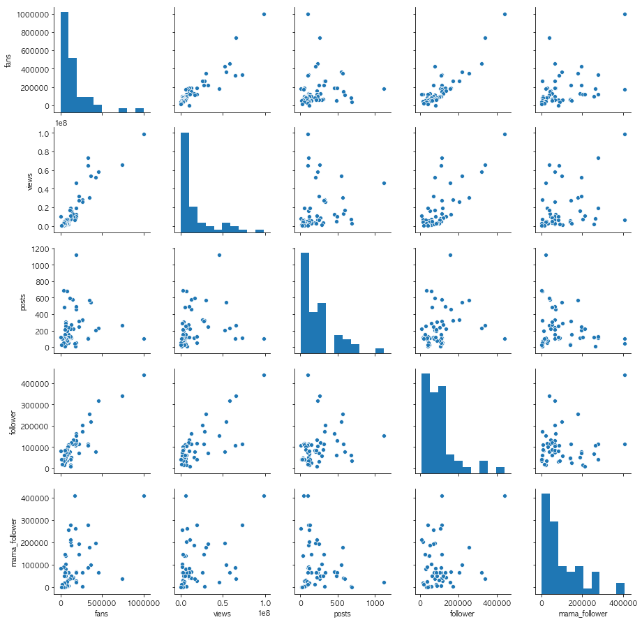

```python
pg = sns.pairplot(df) #, hue='affiliation'
print(type(pg))
```

### ママごとに色分けしてプロット

```python
fig = px.scatter(df, x='mama_follower', y='fans', color='mama',
                  hover_data=['name', 'mama'])
fig.show()
```

[interactive chart not shown]

## 相関係数の確認

0.3～0.5未満：非常に弱い相関とされるようなのでママのフォロワー数とチャンネル登録者数は弱い相関になる

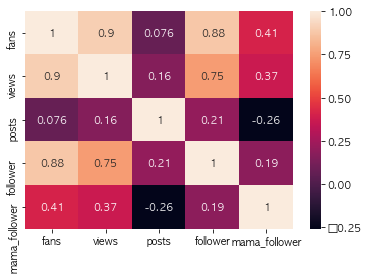

```python
correlation_matrix = np.corrcoef(np.array(df.select_dtypes(include='number')).transpose())
sns.heatmap(correlation_matrix, annot=True,
            xticklabels=['fans', 'views', 'posts', 'follower', 'mama_follower'],
            yticklabels=['fans', 'views', 'posts', 'follower', 'mama_follower'])
plt.show()
```

```python
# チャンネル開設日をunixtimeに変換し、分析日との差異とする。
df['start_date'] = time.time() - df['start_date'].astype('int64') // 10**9
```

```python
# 事務所をダミー変数として持たせる
# "いちから"と"カバー"以外は件数も少ないので
# 個人勢と"いちから"と"カバー"のみonehotのカラムを作る

display(df['affiliation'].value_counts()[:10])
df['ichikara'] = 0
df['cover'] = 0
df['individual'] = 0
df.loc[df['affiliation']=='いちから株式会社',['ichikara']] = 1
df.loc[df['affiliation']=='カバー株式会社',['cover']] = 1
df.loc[df['affiliation']=='おそらく個人勢',['individual']] = 1
```

```
おそらく個人勢                                18
いちから株式会社                               13
カバー株式会社                                 8
株式会社Wright Flyer Live Entertainment     2
THE MOON STUDIO                         2
株式会社枝の上                                 1
upd8                                    1
株式会社DeNA                                1
株式会社アップランド                              1
山佐株式会社                                  1
Name: affiliation, dtype: int64
```

## 回帰分析の実行と結果の解釈

```python
x = df.loc[:, df.select_dtypes(include=['number']).columns.values[1:]].astype('float64')
y = df[['fans']].astype('float64')
```

```python
mscaler = preprocessing.MinMaxScaler()
mscaler.fit(x)
xss_sk = mscaler.transform(x)
mscaler.fit(y)
yss_sk = mscaler.transform(y)
```

```python
xss_sk = pd.DataFrame(xss_sk, columns=df.select_dtypes(include=['number']).columns.values[1:])
yss_sk = pd.DataFrame(yss_sk, columns=['fans'])
```

```python
model_lr_std = LinearRegression()
model_lr_std.fit(xss_sk, yss_sk)

# print(model_lr_std.coef_)
# print(model_lr_std.intercept_)
# print(model_lr_std.score(x, y))
mscaler.inverse_transform(model_lr_std.predict(xss_sk))[:10]
```

```
array([[907727.95490837],
       [702905.4906993 ],
       [505075.23526376],
       [333958.90875202],
       [372172.35229106],
       [382953.11233328],
       [418697.36076804],
       [380178.47606746],
       [291057.13678215],
       [261564.34913064]])
```

```python
x_add_const = sm.add_constant(xss_sk)
model_sm = sm.OLS(yss_sk, x_add_const).fit()
print(model_sm.summary())
```

```
                            OLS Regression Results
==============================================================================
Dep. Variable:                   fans   R-squared:                       0.956
Model:                            OLS   Adj. R-squared:                  0.949
Method:                 Least Squares   F-statistic:                     135.9
Date:                Wed, 22 Jan 2020   Prob (F-statistic):           1.18e-27
Time:                        12:12:40   Log-Likelihood:                 96.957
No. Observations:                  52   AIC:                            -177.9
Df Residuals:                      44   BIC:                            -162.3
Df Model:                           7
Covariance Type:            nonrobust
=================================================================================
                    coef    std err          t      P>|t|      [0.025      0.975]
---------------------------------------------------------------------------------
const            -0.0023      0.019     -0.123      0.903      -0.040       0.036
views             0.3885      0.042      9.244      0.000       0.304       0.473
posts            -0.0504      0.032     -1.574      0.123      -0.115       0.014
start_date        0.1280      0.043      3.006      0.004       0.042       0.214
follower          0.4214      0.051      8.249      0.000       0.318       0.524
mama_follower     0.0770      0.031      2.477      0.017       0.014       0.140
ichikara         -0.0259      0.008     -3.218      0.002      -0.042      -0.010
cover            -0.0259      0.008     -3.218      0.002      -0.042      -0.010
individual       -0.0316      0.015     -2.146      0.037      -0.061      -0.002
==============================================================================
Omnibus:                        3.403   Durbin-Watson:                   1.663
Prob(Omnibus):                  0.182   Jarque-Bera (JB):                2.517
Skew:                          -0.321   Prob(JB):                        0.284
Kurtosis:                       3.866   Cond. No.                     2.14e+16
==============================================================================

Warnings:
[1] Standard Errors assume that the covariance matrix of the errors is correctly specified.
[2] The smallest eigenvalue is 1.7e-31. This might indicate that there are
strong multicollinearity problems or that the design matrix is singular.
```

参照したデータセットに[Marpril](https://www.youtube.com/channel/UCWhv732tk4DAQ7X32qHKrfA)がいないからMarprilで検証する。

```python
# ans 25200fan
mscaler.inverse_transform(model_lr_std.predict(mscaler.transform(np.array([[1303824,
                                                                            55,
                                                                            time.time()  - 1553526000,
                                                                            140000 + 14000,
                                                                            22000,
                                                                            0,
                                                                            0,
                                                                            0]]))))
```

```
array([[3915754.13352427]])
```

## まとめ

あまり親の人気は関係なさそう..